# Quantitative and Risk Management Prerequisites

“This is an article on the prerequisites for quantitative and risk management study.”

QuantBender https://quantbender.github.io (UM6P)http://www.um6p.ma/  
10-01-2024

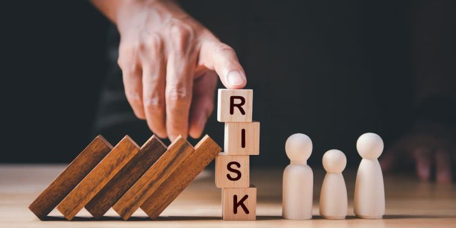

Source: [Quantitative and Risk Management Prerequisites](https://cloudinary.hbs.edu/hbsit/image/upload/s--WzOmNSN1--/f_auto,c_fill,h_375,w_750,/v20200101/80AEA8DCA9AD880564BBF2D6A2581F3F.jpg)

# Introduction

# Finance

Finance is the study of how individuals, businesses, and governments allocate resources over time. It is the science of money management. The following are the prerequisites for studying finance:

- Basic knowledge of financial markets and instruments
- Understanding of financial statements
- Knowledge of financial ratios
- Understanding of the time value of money
- Knowledge of risk and return
- Understanding of capital budgeting

Apart from these key notions, there some principles and notions which are required to the quantification and management of risk within any endeavour (and specifically in the financial world).

- **No Arbitration Opportunity (NOOA) principle**: This principle states that there is no opportunity to make a risk-free profit by exploiting price differences between two or more markets. If there is an arbitrage opportunity, it will be quickly eliminated by market participants.
- **Yield Curve**: Oxford defines it as “*a curve on a graph in which the yield of fixed-interest securities is plotted against the length of time they have to run to maturity*”. So basically, a yield curve gives an idea to an investor of how much he could expect to earn if he lends his money during a certain period of time.

| Types of yield curves | Long term vs short term expectations |
| --- | --- |
| Normal | higher expected returns |
| Inverted | lower expected returns (expectation of decline in inflation) |
| Steep | long-term yields are rising at a faster rate than short-term yields. |
| Flat | all maturities have similar yields |
| Humped | medium-term yields are greater than both short-term yields and long-term yields (slowing of economic groth). |

Yield curves are mainly influenced by **inflation**, **economic growth**, and **interest rates**.

- **How Black-Scholes model is used in trading room?**

This model, taking in account the time and other risk factors, is useful in estimating the theoretical value of derivatives based on different investment instruments (underlying assets in particular). It is a stochastic differential equation widely used to price European options contract because American ones could be exercises before the expiration date. The model requires five input variables: the strike price of the option, the current stock price, the time to expiration, the risk-free rate, and the volatility of the underlying stock. The model is based on the assumption that the price of the underlying asset follows a geometric Brownian motion with constant drift and volatility. The model is used in trading rooms to price options and other derivatives, to hedge risk, and to manage portfolios. The assumptions made by the model are sometimes violated in practice, leading to inaccurate pricing and hedging.

This is the Black-Scholes equation:

$$\frac{\partial V}{\partial t} + \frac{1}{2} \sigma^2 S^2 \frac{\partial^2 V}{\partial S^2} + rS \frac{\partial V}{\partial S} - rV = 0$$
,

where $V$ is the price of the option, $t$ is time, $S$ is the price of the underlying asset, $\sigma$ is the volatility of the underlying asset, and $r$ is the risk-free rate.

We can write the option value as a function of the underlying asset price(S), the current time(t), the strike price(E), the date of expiry(T), the drift of the asset($\mu$), the volatility($\sigma$) of the asset, and the risk-free rate(r).

$$V = V(S, t; \mu, \sigma; E, T; r)$$

- **The Black-Scholes model price is associated with the calculation of sensitivities: Delta, Vega, Gamma, Theta. How are these sensitivities used?**

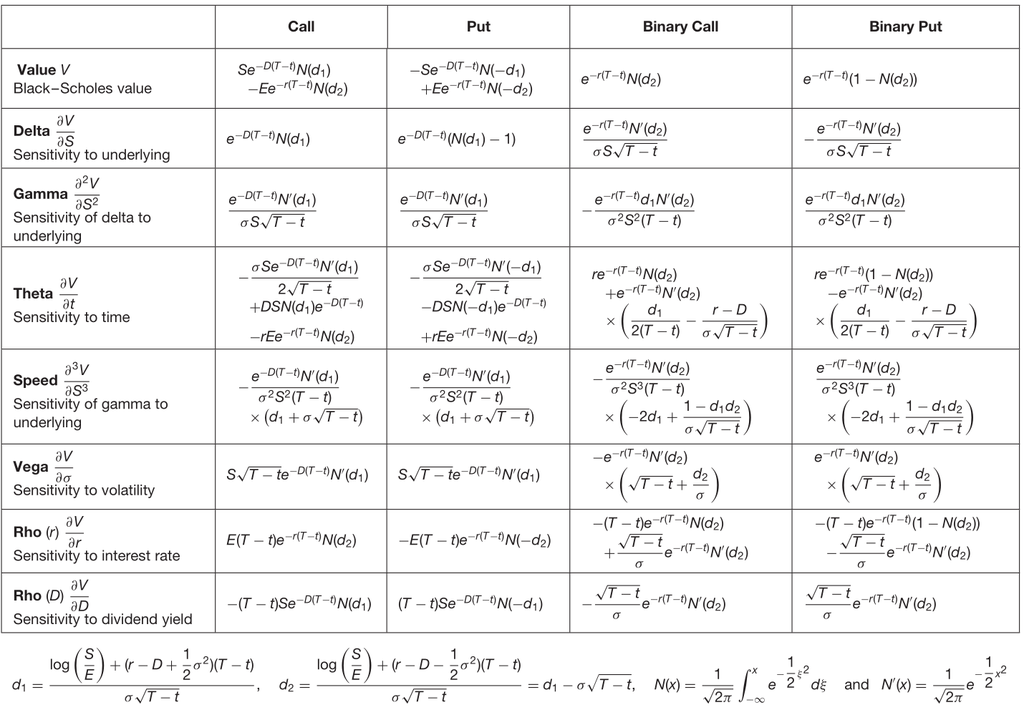

Source: [Paul Wilmott, Introduction to Quantitative Finance, Page 200](https://www.amazon.fr/Paul-Wilmott-Introduces-Quantitative-Finance/dp/0470319585)